# Assignment 4: Matplotlib Excercises

by Arnav Kumar Jain

## 1. Draw a line as shown below (value in y axis are thrice the value in x-axis ). Add a suitable label in the x axis, y axis and a title.

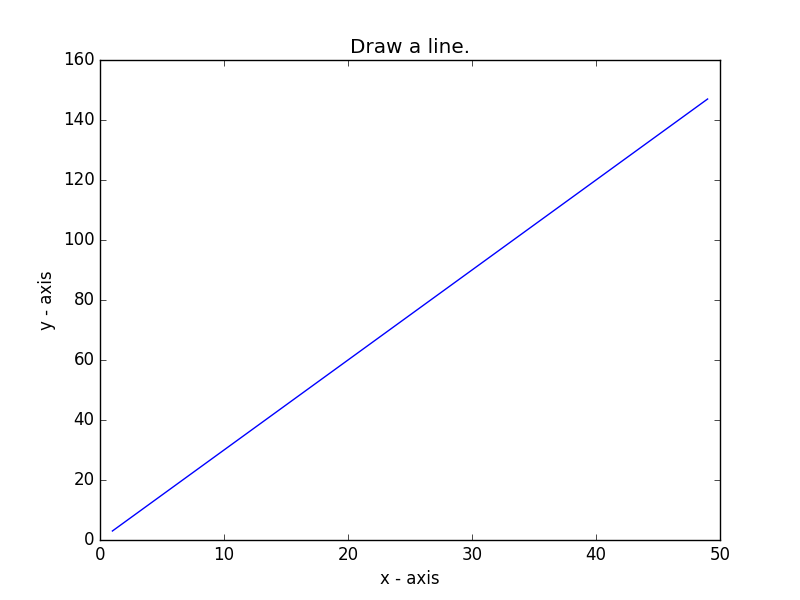

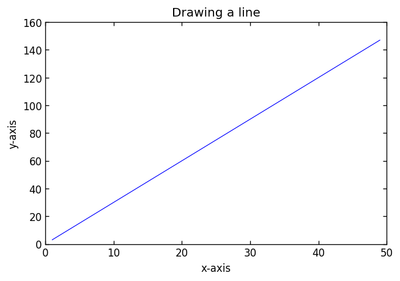

```python
import matplotlib.pyplot as plt
def graph():
    x=[i for i in range(1,50)]
    y=[3*i for i in x]
    ax=plt.figure(dpi=120).gca()
    ax.tick_params(direction="in",top=True,right=True)
    plt.plot(x,y,color="blue",lw=0.7)
    plt.xlabel("x-axis")
    plt.ylabel("y-axis")
    plt.title('Drawing a line')
    plt.xticks([i for i in range (0,51,10)])
    plt.yticks([i for i in range(0,161,20)])
    plt.axis([0,50,0,160])
    plt.show()
if __name__=="__main__":
    graph()
```

## 2. Write a Python program to draw following output

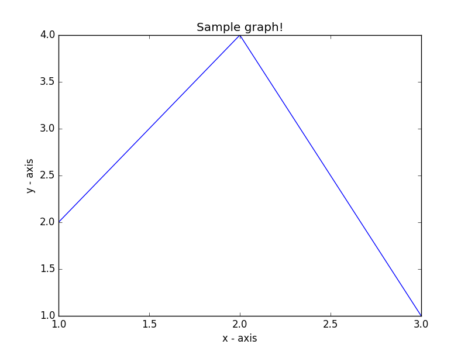

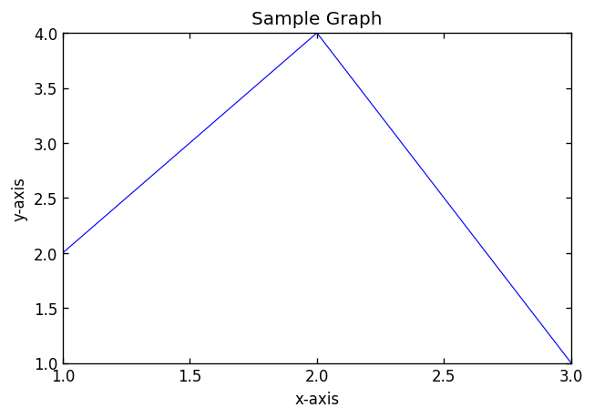

```python
import matplotlib.pyplot as plt
def graph():
    x=[1,2,3]
    y=[2,4,1]
    ax=plt.figure(dpi=120).gca()
    ax.tick_params(direction="in",top=True,right=True)
    plt.plot(x,y,'-',color="blue",lw=0.7)
    plt.axis([1,3,1,4])
    plt.xlabel("x-axis")
    plt.ylabel("y-axis")
    plt.title('Sample Graph')
    plt.xticks([0.5*i for i in range(2,7)])
    plt.show()
if __name__=="__main__":
    graph()
```

| Date | Close |
| --- | --- |
| 03-10-16 | 772.559998 |
| 04-10-16 | 776.429993 |
| 05-10-16 | 776.469971 |
| 06-10-16 | 776.859985 |
| 07-10-16 | 775.080017 |

The code snippet gives the output shown in the following screenshot:

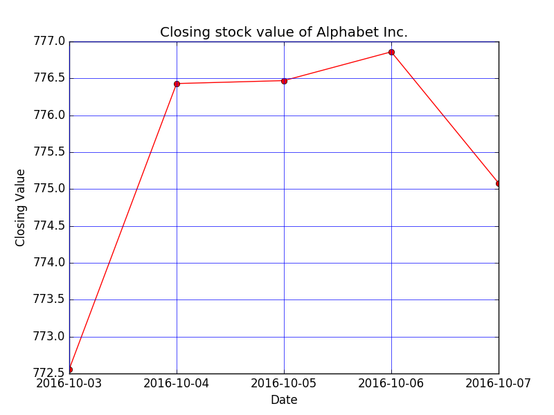

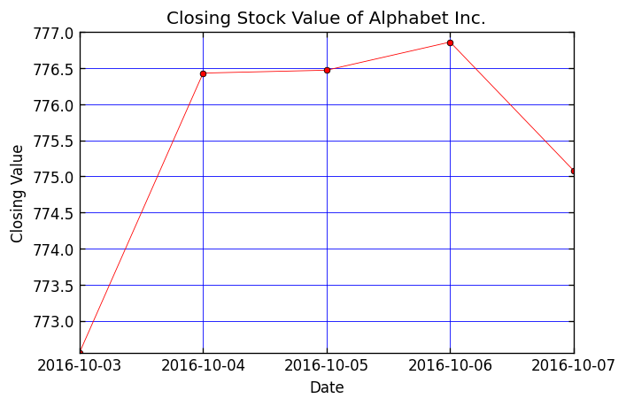

```python
import matplotlib.pyplot as plt
import datetime as dt
def graph():
    x=['03-10-16','04-10-16','05-10-16','06-10-16','07-10-16']
    x=[dt.datetime.strptime(i,'%d-%m-%y') for i in x]
    x=[i.strftime('%Y-%m-%d') for i in x]
    y=[772.559998,776.429993,776.469971,776.859985,775.080017]
    ax=plt.figure(dpi=120).gca()
    ax.tick_params(direction="in",top=True,right=True)
    plt.grid(color='b',ls='-',lw=0.5)
    plt.plot(x,y,'o-',color="red",lw=0.5,mec='k',ms=4,mew=0.5)
    plt.xlabel("Date")
    plt.ylabel("Closing Value")
    plt.title('Closing Stock Value of Alphabet Inc.')
    plt.axis([x[0],x[-1],y[0],777.0])
    plt.show()
if __name__=="__main__":
    graph()
```

## 4. Plot two lines as shown below with appropriate legends, different widths and colors.

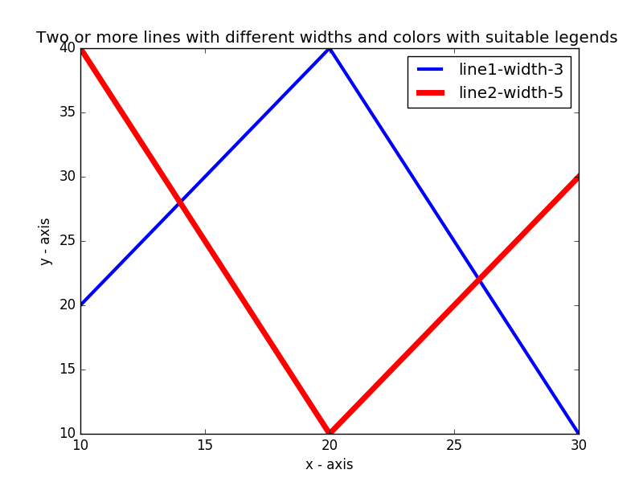

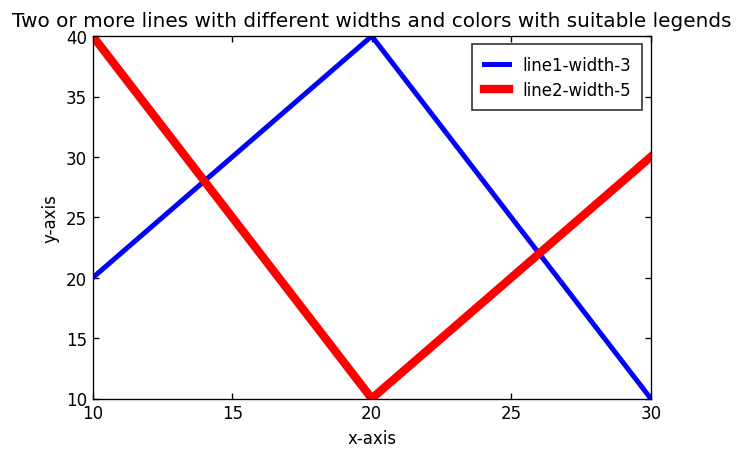

```python
import matplotlib.pyplot as plt
def graph():
    ax=plt.figure(dpi=120).gca()
    ax.tick_params(direction="in",top=True,right=True)
    plt.plot([10,20,30],[20,40,10],'-',color="blue",lw=3,label="line1-width-3")
    plt.plot([10,20,30],[40,10,30],'-',color="red",lw=5,label='line2-width-5')
    plt.axis([10,30,10,40])
    plt.xlabel("x-axis")
    plt.ylabel("y-axis")
    plt.xticks([i for i in range(10,31,5)])
    plt.title('Two or more lines with different widths and colors with suitable legends')
    plt.legend(edgecolor='black',fancybox=False,borderpad=0.7,handletextpad=0.8,handlelength=1.5,labelspacing=0.4)
    plt.show()
if __name__=="__main__":
    graph()
```

## 5. Display a bar chart of the popularity of programming Languages. Attach a text label above each bar displaying its popularity (float value). Use different color for each bar. Make blue border to each bar.

Sample data:

Programming languages: Java, Python, PHP, JavaScript, C#, C++  
Popularity: 22.2, 17.6, 8.8, 8, 7.7, 6.7

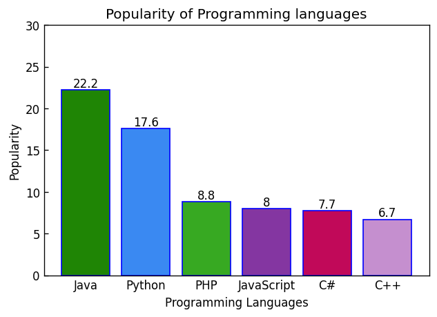

```python
import matplotlib.pyplot as plt
import random
def graph():
    ax=plt.figure(dpi=120).gca()
    ax.tick_params(direction="in",top=False,right=False,bottom=False)
    x=['Java','Python','PHP','JavaScript','C#','C++']
    y=[22.2, 17.6, 8.8, 8, 7.7, 6.7]
    color=[(random.random(),random.random(),random.random()) for i in x]
    plt.bar(x,y,color=color,ec='b')
    for i in range(len(x)):
        plt.annotate(y[i],xy=(x[i],y[i]),ha="center",va="bottom")
    plt.title("Popularity of Programming languages")
    plt.xlabel("Programming Languages")
    plt.ylabel("Popularity")
    plt.ylim(top=30)
    plt.show()
if __name__=="__main__":
    graph()
```

## 6. Convert bar chart of Q5 into horizontal bar chart and increase its bottom margin.

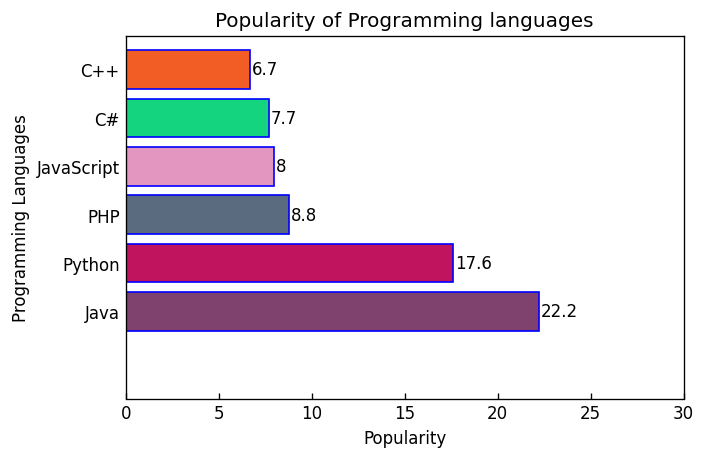

```python
import matplotlib.pyplot as plt
import random
def graph():
    ax=plt.figure(dpi=120).gca()
    ax.tick_params(direction="in",top=False,right=False,left=False)
    x=['Java','Python','PHP','JavaScript','C#','C++']
    y=[22.2, 17.6, 8.8, 8, 7.7, 6.7]
    color=[(random.random(),random.random(),random.random()) for i in x]
    plt.barh(x,y,color=color,ec='b')
    for i in range(len(x)):
        plt.text(s=y[i],x=y[i]+0.1,y=i,va='center',ha="left")
    plt.title("Popularity of Programming languages")
    plt.ylabel("Programming Languages")
    plt.xlabel("Popularity")
    plt.xlim(right=30)
    plt.ylim(bottom=-1.8)
    plt.show()
if __name__=="__main__":
    graph()
```

## 7. Create bar plot of scores by group and gender. Use multiple X values on the same chart for men and women.

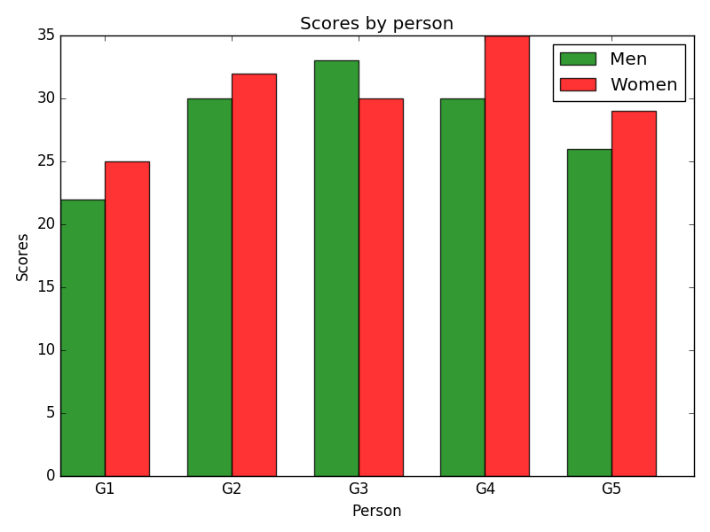

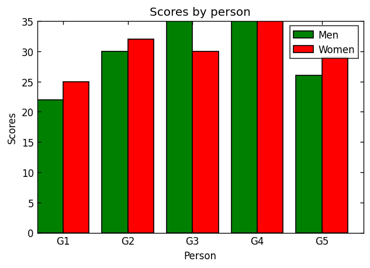

```python
import matplotlib.pyplot as plt
import random
def graph():
    ax=plt.figure(dpi=120).gca()
    ax.tick_params(direction="in",top=True,right=True,bottom=True)
    x=['G1','G2','G3','G4','G5']
    Men=(22, 30, 35, 35, 26)
    Women=(25, 32, 30, 35, 29)
    b1=plt.bar([i-0.20 for i in range(len(x))],Men,color='g',ec='k',width=0.4)
    b2=plt.bar([i+0.20 for i in range(len(x))],Women,color='r',ec='k',width=0.4)
    plt.title("Scores by person")
    plt.xlabel("Person")
    plt.ylabel("Scores")
    plt.xlim(left=0-0.40)
    plt.xticks(range(len(x)),labels=x)
    plt.legend([b1,b2],['Men','Women'],edgecolor='black',fancybox=False,borderpad=0.4,handletextpad=0.5,labelspacing=0.4)

    plt.ylim(top=35)
    plt.show()
if __name__=="__main__":
    graph()
```

## 8. Write a Python program to create stack bar plot and add label to each section.

Sample data:  
people = ('G1','G2','G3','G4','G5','G6','G7','G8')  
segments = 4

## Multi-dimensional data

data = [[ 3.40022085, 7.70632498, 6.4097905, 10.51648577, 7.5330039, 7.1123587, 12.77792868, 3.44773477], [ 11.24811149, 5.03778215, 6.65808464, 12.32220677, 7.45964195, 6.79685302, 7.24578743, 3.69371847], [ 3.94253354, 4.74763549, 11.73529246, 4.6465543, 12.9952182, 4.63832778, 11.16849999, 8.56883433], [ 4.24409799, 12.71746612, 11.3772169, 9.00514257, 10.47084185, 10.97567589, 3.98287652, 8.80552122]]

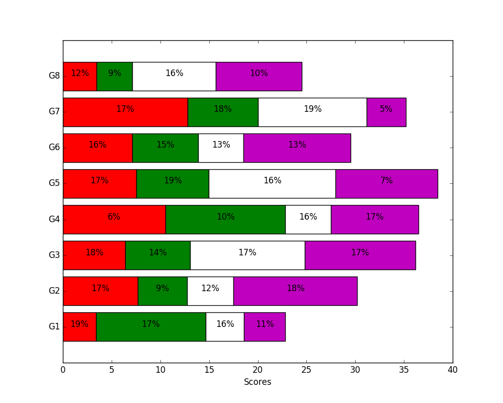

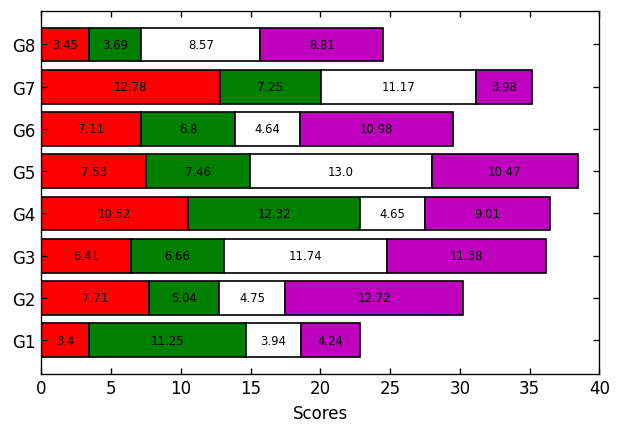

```python
import matplotlib.pyplot as plt
def graph():
    ax=plt.figure(dpi=120).gca()
    ax.tick_params(direction="in",top=True,right=True,left=True)
    people = ('G1','G2','G3','G4','G5','G6','G7','G8')
    segments = 4
    color="rgwm"
    data = [[3.40022085, 7.70632498, 6.4097905, 10.51648577, 7.5330039, 7.1123587, 12.77792868, 3.44773477], [ 11.24811149, 5.03778215, 6.65808464, 12.32220677, 7.45964195, 6.79685302, 7.24578743, 3.69371847], [ 3.94253354, 4.74763549, 11.73529246, 4.6465543, 12.9952182, 4.63832778, 11.16849999, 8.56883433], [ 4.24409799, 12.71746612, 11.3772169, 9.00514257, 10.47084185, 10.97567589, 3.98287652, 8.80552122]]
    for i in range(len(data)):
        plt.barh(people,data[i],color=color[i],ec='k',height=0.8,left=0 if i==0 else [sum(x) for x in zip(*data[:i])])
        for j in range(len(data[i])):
            plt.annotate(s=round(data[i][j],2),xy=((0 if i==0 else [sum(x) for x in zip(*data[:i])][j])+data[i][j]/2,j),va='center',ha='center',size=7)
    plt.xlabel("Scores")
    plt.xlim(left=0,right=40)
    plt.show()
if __name__=="__main__":
    graph()
    print()
```

## 9. Create a pie chart of the popularity of programming Languages. Add a title to this pie chart. Use sample data given in Q5.

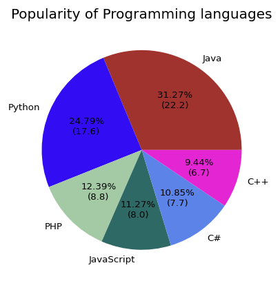

```python
import matplotlib.pyplot as plt
import random
def graph():
    ax=plt.figure(dpi=120).gca()
    ax.tick_params(direction="in",top=False,right=False,bottom=False)
    x=['Java','Python','PHP','JavaScript','C#','C++']
    y=[22.2, 17.6, 8.8, 8, 7.7, 6.7]
    color=[(random.random(),random.random(),random.random()) for i in x]
    plt.pie(y,labels=x,colors=color,autopct=lambda p: '{:.2f}%\n({:1.1f})'.format(p,(p/100)*sum(y)),textprops={'size':8})
    plt.title("Popularity of Programming languages")
    plt.show()
if __name__=="__main__":
    graph()
    print()
```

## 10. Create a pie chart of gold medal achievements of five most successful countries in 2016 Summer Olympics. Read the data from a csv file.

Sample data: medal.csv

| country | gold_medal |
| --- | --- |
| United States | 46 |
| Great Britain | 27 |
| China | 26 |
| Russia | 19 |
| Germany | 17 |

```python
from google.colab import drive
drive.mount('/content/drive')
```

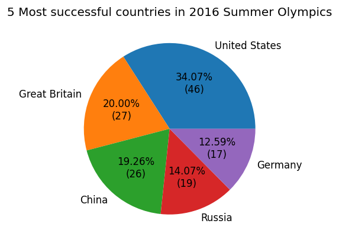

```python
import matplotlib.pyplot as plt
import pandas as pd
def graph():
    path="/content/drive/MyDrive/Colab Notebooks/medal.csv"
    df=pd.read_csv(path)
    ax=plt.figure(dpi=120).gca()
    ax.tick_params(direction="in",top=False,right=False,bottom=False)
    plt.pie(df.iloc[:,1],labels=df.iloc[:,0],autopct=lambda p: '{:.2f}%\n({:1.0f})'.format(p,(p/100)*sum(df.iloc[:,1])))
    plt.title("5 Most successful countries in 2016 Summer Olympics")
    plt.show()
if __name__=="__main__":
    graph()
    print()
```

## 11. Write a Python program to draw a scatter graph taking a randomdistribution in X and Y and plotted against each other.

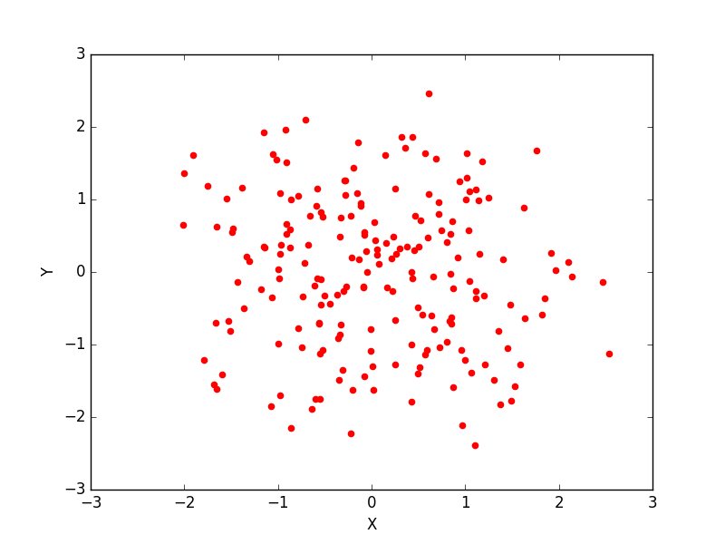

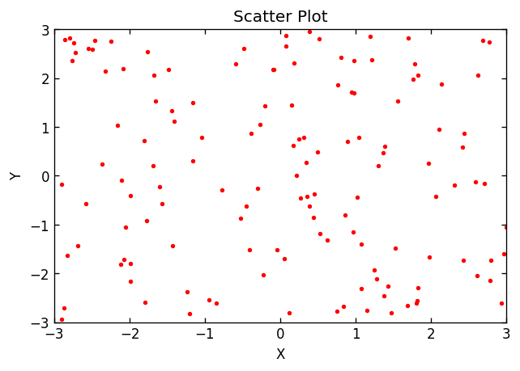

```python
import matplotlib.pyplot as plt
import random
def graph():
    ax=plt.figure(dpi=120).gca()
    ax.tick_params(direction="in",top=True,right=True,bottom=True)
    lim=random.randint(100,150)
    plt.axis([-3,3,-3,3])
    x=[random.uniform(-3,3) for i in range(lim)]
    y=[random.uniform(-3,3) for i in range(lim)]
    plt.scatter(x,y,c='r',s=5)
    plt.title("Scatter Plot")
    plt.xlabel("X")
    plt.ylabel("Y")
    plt.show()
if __name__=="__main__":
    graph()
```

```python
!cp  "/content/drive/MyDrive/Colab Notebooks/Assignment 4.ipynb"
!jupyter nbconvert --to html "Assignment 4.ipynb"
```

[output not shown]

[output cut: 76 more lines]

[output not shown]